# Experimental Design

Pietro Franceschi | pietro.franceschi@fmach.it

## Statistics

**Statistics** is the science which deals with **the collection, the analysis, the visualization and the interpretation** of experimental data.

## How data are collected …

- Random samplings
- Observational studies
- Experiments

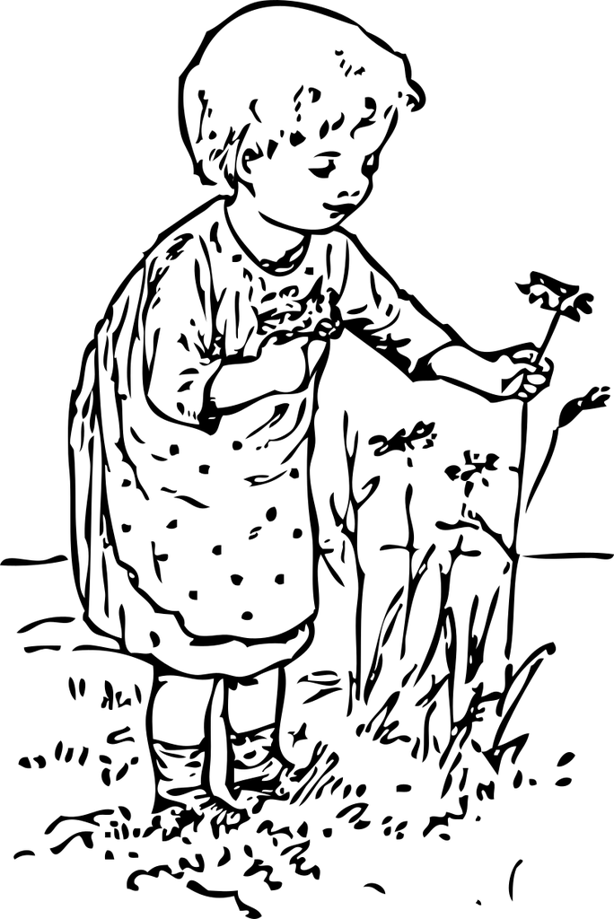

## Random Samplings (polls)

⚠️ **Definition:**  
Random samplings allow to characterize the properties of a finite population without measuring all of its members.

**Examples**

- *Electoral polls*
- *Normal levels of cholesterol in the human population*
- *Characterization of a population of grapes, apples, wines, …*

## Observational Studies

⚠️ **Definition:**  
Observational studies are designed with the objective of **identifying relationships** between the different properties of a conceptual population. The role of the experimenter is to perform the **selection of the sample**.

**Examples**

- *Is it true that people who eat more chocolate are more happy?*
- *The level of cholesterol of people eating more vegetables is lower*

## Experiments

⚠️ **Definition:**  
**Experiments** are designed with the objective of identifying **causal relations** between the properties of a conceptual population. The role of the experimenter is to **modify the conditions** to verify the presence of causal relationship between the observed properties.

**Examples**

- *If you eat more chocolate you will get happier*
- *If I drink more beer I’ll get more sympathetic*

## Important notes

- Causal relations can be assessed only in **experiments**
- This is really Galileian ;-)
- Experiments are impossible in many relevant fields like human health and ecology

Should we then give up on obtaining causal information there?

## Mind the chocolate …

[figure not shown]

*New England Journal of Medicine, 2012*

*” … Chocolate consumption enhances cognitive function, which is a sine qua non for winning the Nobel Prize, and it closely correlates with the number of Nobel laureates in each country …“* [**…and more!**](https://tylervigen.com/spurious-correlations)

## Planning a sampling

⚠️ **Key question**  
What is the best way to sample my population in a representative way?

- Do it randomly to avoid any intentional or unintentional bias (**Randomized Sampling**)
- Take into account known subpopulations and confounding factors (**Stratified Random Sampling**)
- The number of samples is determined by practical/economical considerations

In presence of known subpopulations, stratified random sampling results in a more accurate characterization of the population

## Stratified Random Sampling

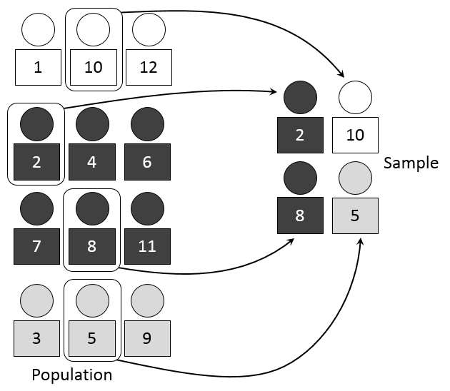

## Key idea: do it randomly

The most reasonable way to “smear out” the effects of unknown biases is to do everything **randomly**

Random is not a synonym of HAPHAZARD

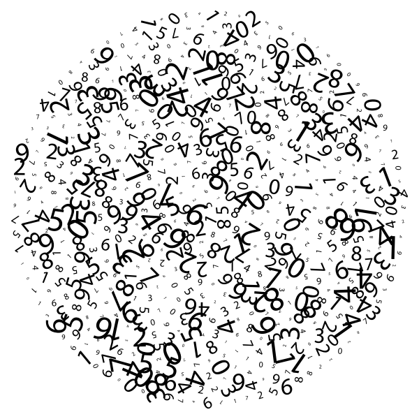

## Planning an observational study

**Objective:** get a useful and clear answer.  
**Means:** start from a clear, useful and often simple question.

- Identify the **sampling unit**
- Decide the number of samples (money, power, …)
- Define the conceptual population
- Sample it in a representative way
- Identify **confounding factors** and, if possible, **stratify** for them

## Key idea: Sampling Unit

The smaller unit of a population which retains the properties we are interested in.

- *Example: grapevine, leafs, infections …*

## Key idea: Confounding Factor

A variable that influences both the dependent variable and independent variable, causing a spurious association (*wikipedia*).

- *Smoke, cardiovascular disease, alcohol consumption*
- *Birth order (1st child, 2nd child, etc.), maternal age, Down Syndrome in the child*

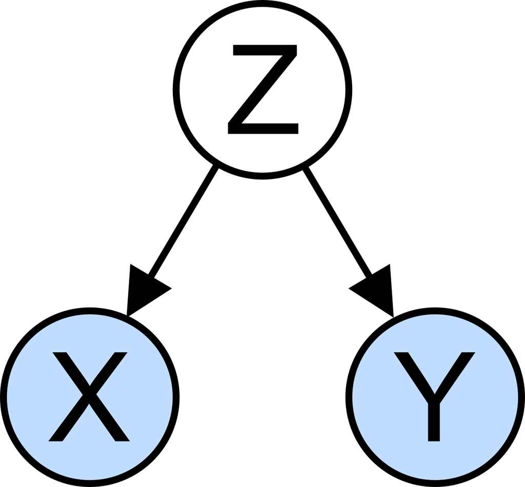

## Notes

- Some confounders can be controlled by careful sampling
  - *Age and Gender on the relation between happiness and chocolate*
- Some others are impossible to control
  - *Presence of chemical pollution in water streams and altitude of sampling*

## Planning one experiment

**Objective:** get a useful and clear answer.  
**Means:** start from a clear, useful and often simple question.

- What is my **experimental unit**?
- How many samples should I measure?
- What are the **potential sources of variability**?

## Experimental Design

⚠️ **Definition**  
A strategy to assign the experimental units to the different *treatments* to optimize my capacity of inferring **causal relationships**.

Control of unwanted sources of variability (technical/biological) to highlight the effects of the intervention

The tools: **randomization** and **blocking**

## Key tool: Blocking

- Group experimental units in homogeneous groups (**blocks**)
- Perform a “full” experiment within each block (blocks and study factors will be **orthogonal**)
- Identify and subtract the variability across the blocks

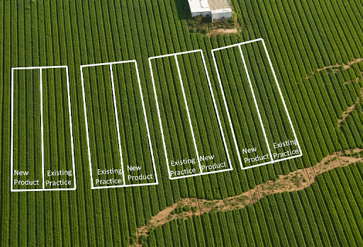

**Block what you can; randomize what you cannot …**

## Examples of common blocking factors

- Location
- Analytical batch
- Day
- Operator

[figure not shown]

## Randomized Complete Designs

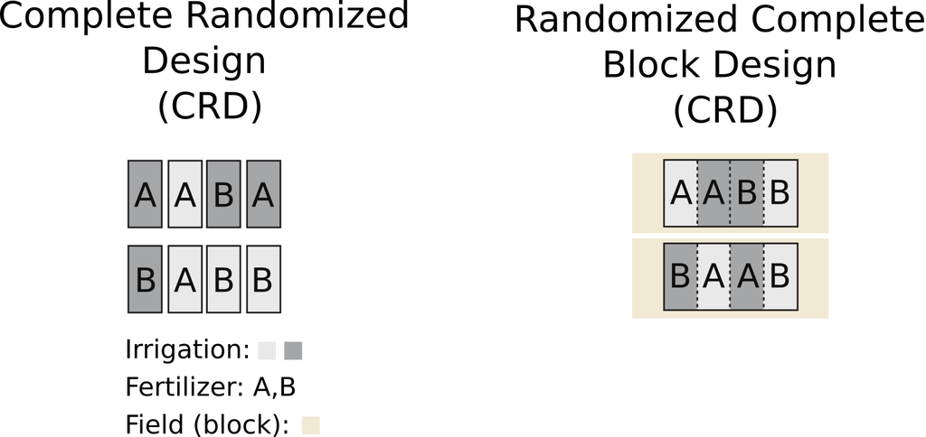

## Split Plot Designs

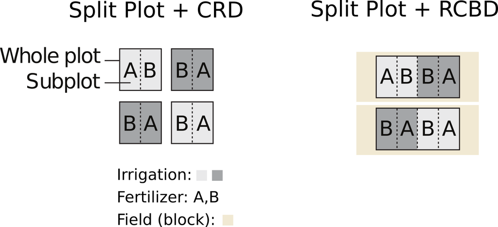

## Longitudinal Studies

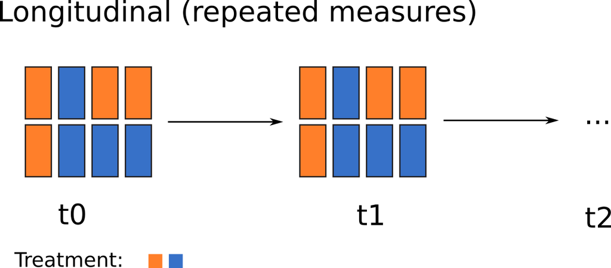

## Crossover Studies

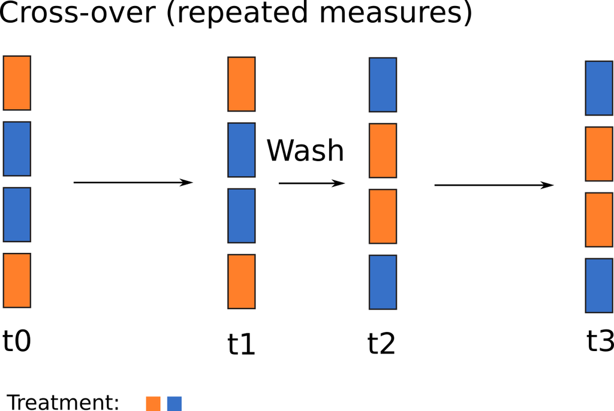

## Notes

- Block as much as possible!
- Repeated measures are more “powerful” because each unit is the control of itself
- Crossovers can be tricky for the wash-out
- Repeated measures designs are key when population variability is large (e.g. plants in the field/greenhouse)